# Exercise4 : Manipulating Geospatial Data

Python

Code

Geopandas

Author

Jinwon Lee

Published

April 29, 2023

> Kaggle Geospatial Analysis Exercise 4

**이 노트북은 Kaggle [Geospatial Analysis](https://www.kaggle.com/learn/geospatial-analysis)의 Exercise 입니다. 이 [링크](https://jw0112.github.io/blog/Data_Mining/Geospatial_Analysis/Geospatial_Analysis#lesson-4-manipulating-geospatial-data)로 튜토리얼을 볼 수 있습니다.**

# 소개

당신은 스타벅스 리저브 로스터리로 전환할 다음 매장을 찾고 있는 스타벅스 빅데이터 전문가([실존하는 직업](https://www.forbes.com/sites/bernardmarr/2018/05/28/starbucks-using-big-data-analytics-and-artificial-intelligence-to-boost-performance/#130c7d765cdc))입니다.

스타벅스 리저브 로스터리는 일반 스타벅스 매장보다 훨씬 더 크고 다양한 음식과 와인, 고급 라운지 공간 등 여러가지 추가 기능을 갖추고 있습니다.

캘리포니아 주 내 여러 지방의 인구 통계를 조사하여 잠재적으로 적합한 위치를 결정합니다.

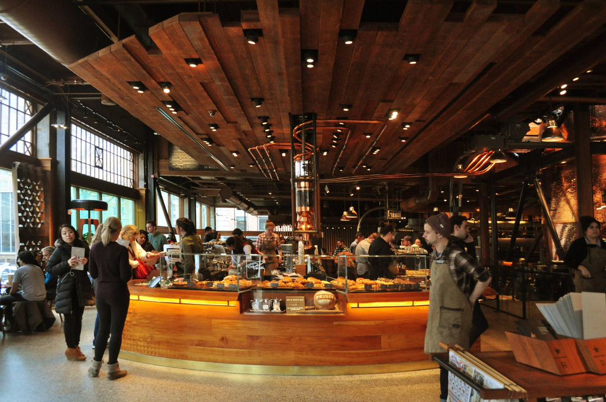

```python
import warnings
warnings.filterwarnings(action = 'ignore')

import math
import numpy as np
import pandas as pd
import geopandas as gpd
from geopy.geocoders import Nominatim

import folium
from folium import Marker
from folium.plugins import MarkerCluster
```

`embed_map()` 함수를 사용해 지도를 시각화해봅시다.

```python
def embed_map(m, file_name) :
    from IPython.display import IFrame
    m.save(file_name)
    return IFrame(file_name, width = '100%', height = '500px')
```

### 1) 누락된 위치 지오코딩

캘리포니아 주의 스타벅스의 위치를 포함하는 `starbucks`라는 DataFrame을 생성합니다.

```python
starbucks = pd.read_csv('./geospatial-learn-course-data/starbucks_locations.csv')
starbucks.head()
```

|  | Store Number | Store Name | Address | City | Longitude | Latitude |
| --- | --- | --- | --- | --- | --- | --- |
| 0 | 10429-100710 | Palmdale & Hwy 395 | 14136 US Hwy 395 Adelanto CA | Adelanto | -117.40 | 34.51 |
| 1 | 635-352 | Kanan & Thousand Oaks | 5827 Kanan Road Agoura CA | Agoura | -118.76 | 34.16 |
| 2 | 74510-27669 | Vons-Agoura Hills #2001 | 5671 Kanan Rd. Agoura Hills CA | Agoura Hills | -118.76 | 34.15 |
| 3 | 29839-255026 | Target Anaheim T-0677 | 8148 E SANTA ANA CANYON ROAD AHAHEIM CA | AHAHEIM | -117.75 | 33.87 |
| 4 | 23463-230284 | Safeway - Alameda 3281 | 2600 5th Street Alameda CA | Alameda | -122.28 | 37.79 |

대부분의 매장의 위도와 경도는 알고 있습니다. 하지만, 버클리 시의 모든 위치가 누락되어 있습니다.

```python
print(starbucks[['Longitude', 'Latitude']].isnull().sum(), '\n')

rows_with_missing = starbucks[starbucks['City'] == 'Berkeley']
rows_with_missing
```

```
Longitude    5
Latitude     5
dtype: int64
```

|  | Store Number | Store Name | Address | City | Longitude | Latitude |
| --- | --- | --- | --- | --- | --- | --- |
| 153 | 5406-945 | 2224 Shattuck - Berkeley | 2224 Shattuck Avenue Berkeley CA | Berkeley | NaN | NaN |
| 154 | 570-512 | Solano Ave | 1799 Solano Avenue Berkeley CA | Berkeley | NaN | NaN |
| 155 | 17877-164526 | Safeway - Berkeley #691 | 1444 Shattuck Place Berkeley CA | Berkeley | NaN | NaN |
| 156 | 19864-202264 | Telegraph & Ashby | 3001 Telegraph Avenue Berkeley CA | Berkeley | NaN | NaN |
| 157 | 9217-9253 | 2128 Oxford St. | 2128 Oxford Street Berkeley CA | Berkeley | NaN | NaN |

아래 셀을 사용하여 `Nominatim` geocoder로 누락된 값을 채우세요.

| 튜토리얼에서는 `geopy.geocoders`의 `Nominatim()`을 사용하여 값을 지오코딩했으며, 이 강좌 외의 프로젝트에서도 이 함수를 사용할 수 있습니다. |
| --- |
| 이 연습에서는 약간 다른 함수 `Nominatim()`(`learntools.geospatial.tools` 내장 함수)을 사용합니다. 이 함수는 GeoPandas의 함수와 동일하게 작동합니다. |
| 즉, import 문을 변경하지 않는 한 노트북 상단의 가져오기 문을 변경하지 않고, 아래 코드 셀에서 지오코딩 함수를 `geocode()`로 호출하기만 하면 됩니다. |

```python
geolocator = Nominatim(user_agent = 'kaggle_learn')

def my_geocoder(row) :
    try :
        point = geolocator.geocode(row).point
        return pd.Series({'Latitude' : point.latitude, 'Longitude' : point.longitude})
    except :
        return None

rows_with_missing[['Latitude', 'Longitude']] = rows_with_missing.apply(lambda x : my_geocoder(x['Address']), axis = 1)

starbucks.update(rows_with_missing[['Latitude', 'Longitude']])

print('{}% of addresses were geocoded!'.format(
    (1 - sum(np.isnan(starbucks['Latitude'])) / len(starbucks)) * 100))
```

```
100.0% of addresses were geocoded!
```

### 2) 버클리 지역 시각화

방금 찾은 위치를 살펴봅시다. 버클리의 위도, 경도를 OpenStreetMap 스타일로 시각화해보세요.

```python
m_2 = folium.Map(location = [37.88, -122.26], tiles = 'openstreetmap', zoom_start = 13)

for idx, row in starbucks[starbucks['City'] == 'Berkeley'].iterrows() :
    Marker([row['Latitude'], row['Longitude']], popup = row['Store Name']).add_to(m_2)

m_2 # embed_map(m_2, 'q_2.html')
```

Make this Notebook Trusted to load map: File -> Trust Notebook

[interactive chart not shown]

버클리의 5개의 매장만 고려했을 때, 몇 개의 매장이 잠재적으로 정확(정확히 도시에 위치)해 보이나요?

**5개 매장 모두 정확** 해 보입니다.

### 3) 데이터 통합

아래 셀을 사용하여 캘리포니아 주의 각 지방에 대한 이름, 면적(km²) 및 고유ID(`GEOID` 열)가 포함된 `CA_counties` GeoDataFrame을 로드합니다.

`geometry` 열에는 각 지방의 경계가 있는 Polygon이 포함되어 있습니다.

```python
CA_counties = gpd.read_file('./geospatial-learn-course-data/CA_county_boundaries/CA_county_boundaries/CA_county_boundaries.shp')
CA_counties.head()
```

|  | GEOID | name | area_sqkm | geometry |
| --- | --- | --- | --- | --- |
| 0 | 6091 | Sierra County | 2491.995494 | POLYGON ((-120.65560 39.69357, -120.65554 39.6... |
| 1 | 6067 | Sacramento County | 2575.258262 | POLYGON ((-121.18858 38.71431, -121.18732 38.7... |
| 2 | 6083 | Santa Barbara County | 9813.817958 | MULTIPOLYGON (((-120.58191 34.09856, -120.5822... |
| 3 | 6009 | Calaveras County | 2685.626726 | POLYGON ((-120.63095 38.34111, -120.63058 38.3... |
| 4 | 6111 | Ventura County | 5719.321379 | MULTIPOLYGON (((-119.63631 33.27304, -119.6360... |

다음으로, 우리는 3개의 DataFrame을 생성합니다.

- `CA_pop`에는 각 지방의 인구 추정치가 포함됩니다.
- `CA_high_earners`에는 연간 소득이 $150,000 이상인 가구 수가 포함됩니다.
- `CA_median_age`에는 각 지방의 평균 연령을 포함합니다.

```python
CA_pop = pd.read_csv('./geospatial-learn-course-data/CA_county_population.csv', index_col = 'GEOID')
CA_high_earners = pd.read_csv('./geospatial-learn-course-data/CA_county_high_earners.csv', index_col = 'GEOID')
CA_median_age = pd.read_csv('./geospatial-learn-course-data/CA_county_median_age.csv', index_col = 'GEOID')
```

아래 셀을 사용하여 `CA_counties` GeoDataFrame과 `CA_pop`, `CA_high_earners`, `CA_median_age`과 조인하세요.

또한 CRS가 `{'init' : 'epsg:4326'}`으로 설정되어 있는지 확인하세요.

```python
CA_all = CA_pop.join([CA_high_earners, CA_median_age]).reset_index()
CA_stats = CA_counties.merge(CA_all, on = 'GEOID')
CA_stats.crs = {'init' : 'epsg:4326'}
CA_stats.head()
```

|  | GEOID | name | area_sqkm | geometry | population | high_earners | median_age |
| --- | --- | --- | --- | --- | --- | --- | --- |
| 0 | 6091 | Sierra County | 2491.995494 | POLYGON ((-120.65560 39.69357, -120.65554 39.6... | 2987 | 111 | 55.0 |
| 1 | 6067 | Sacramento County | 2575.258262 | POLYGON ((-121.18858 38.71431, -121.18732 38.7... | 1540975 | 65768 | 35.9 |
| 2 | 6083 | Santa Barbara County | 9813.817958 | MULTIPOLYGON (((-120.58191 34.09856, -120.5822... | 446527 | 25231 | 33.7 |
| 3 | 6009 | Calaveras County | 2685.626726 | POLYGON ((-120.63095 38.34111, -120.63058 38.3... | 45602 | 2046 | 51.6 |
| 4 | 6111 | Ventura County | 5719.321379 | MULTIPOLYGON (((-119.63631 33.27304, -119.6360... | 850967 | 57121 | 37.5 |

이제 모든 데이터가 한 곳에 있으므로 열의 조합으로 통계량을 계산하는 것이 훨씬 쉬워졌습니다.

다음 셀을 실행하여 인구 밀도가 포함된 `density` 열을 만들어보세요.

```python
CA_stats['density'] = CA_stats['population'] / CA_stats['area_sqkm']
CA_stats.head()
```

|  | GEOID | name | area_sqkm | geometry | population | high_earners | median_age | density |
| --- | --- | --- | --- | --- | --- | --- | --- | --- |
| 0 | 6091 | Sierra County | 2491.995494 | POLYGON ((-120.65560 39.69357, -120.65554 39.6... | 2987 | 111 | 55.0 | 1.198638 |
| 1 | 6067 | Sacramento County | 2575.258262 | POLYGON ((-121.18858 38.71431, -121.18732 38.7... | 1540975 | 65768 | 35.9 | 598.376878 |
| 2 | 6083 | Santa Barbara County | 9813.817958 | MULTIPOLYGON (((-120.58191 34.09856, -120.5822... | 446527 | 25231 | 33.7 | 45.499825 |
| 3 | 6009 | Calaveras County | 2685.626726 | POLYGON ((-120.63095 38.34111, -120.63058 38.3... | 45602 | 2046 | 51.6 | 16.980022 |
| 4 | 6111 | Ventura County | 5719.321379 | MULTIPOLYGON (((-119.63631 33.27304, -119.6360... | 850967 | 57121 | 37.5 | 148.788107 |

### 4) 어떤 지방이 유망해보이나요?

모든 정보를 하나의 GeoDataFrame으로 축소하면 특정 기준을 충족하는 지방을 훨씬 쉽게 선택할 수 있습니다.

다음 셀을 사용하여 `CA_stats` GeoDataFrame에서 행의 하위 집합 (및 모든 열)을 포함하는 `sel_counties` GeoDataFrame을 만듭니다.

- 연간 소득 $150,000를 버는 가구가 최소 10만 가구 이상
- 연령 중앙값이 38.5세 미만
- 주민 밀도가 최소 285명(km² 당) 이상

추가적으로, 선정된 지방은 다음 기준 중 하나 이상을 충족해야합니다.

- 연간 소득이 $150,000 이상인 가구가 최소 50만 가구 이상
- 연령 중앙값이 35.5세 미만
- 주민 밀도가 최소 1400명(km² 당) 이상

```python
sel_counties = CA_stats[(CA_stats['high_earners'] >= 100000) & (CA_stats['median_age'] < 38.5) & (CA_stats['density'] >= 285) &
                        ((CA_stats['high_earners'] >= 500000) | (CA_stats['median_age'] < 35.5) | (CA_stats['density'] >= 1400))]
sel_counties
```

|  | GEOID | name | area_sqkm | geometry | population | high_earners | median_age | density |
| --- | --- | --- | --- | --- | --- | --- | --- | --- |
| 5 | 6037 | Los Angeles County | 12305.376879 | MULTIPOLYGON (((-118.66761 33.47749, -118.6682... | 10105518 | 501413 | 36.0 | 821.227834 |
| 8 | 6073 | San Diego County | 11721.342229 | POLYGON ((-117.43744 33.17953, -117.44955 33.1... | 3343364 | 194676 | 35.4 | 285.237299 |
| 10 | 6075 | San Francisco County | 600.588247 | MULTIPOLYGON (((-122.60025 37.80249, -122.6123... | 883305 | 114989 | 38.3 | 1470.733077 |

### 5) 몇 개의 매장이 식별되었나요?

다음 스타벅스 리저브 로스터리 매장을 찾을 때 선택한 지방 내의 모든 매장을 고려하고 싶을 것입니다.

그렇다면, 선택한 지방 내에 몇 개의 매장이 있을까요?

다음 셀을 실행하여 이 질문에 답을 할 수 있도록 모든 스타벅스 위치가 포함된 `starbucks_gdf` GeoDataFrame을 생성하세요.

```python
starbucks_gdf = gpd.GeoDataFrame(starbucks, geometry = gpd.points_from_xy(starbucks['Longitude'], starbucks['Latitude']))
starbucks_gdf.crs = {'init' : 'epsg:4326'}
starbucks_gdf.head()
```

|  | Store Number | Store Name | Address | City | Longitude | Latitude | geometry |
| --- | --- | --- | --- | --- | --- | --- | --- |
| 0 | 10429-100710 | Palmdale & Hwy 395 | 14136 US Hwy 395 Adelanto CA | Adelanto | -117.40 | 34.51 | POINT (-117.40000 34.51000) |
| 1 | 635-352 | Kanan & Thousand Oaks | 5827 Kanan Road Agoura CA | Agoura | -118.76 | 34.16 | POINT (-118.76000 34.16000) |
| 2 | 74510-27669 | Vons-Agoura Hills #2001 | 5671 Kanan Rd. Agoura Hills CA | Agoura Hills | -118.76 | 34.15 | POINT (-118.76000 34.15000) |
| 3 | 29839-255026 | Target Anaheim T-0677 | 8148 E SANTA ANA CANYON ROAD AHAHEIM CA | AHAHEIM | -117.75 | 33.87 | POINT (-117.75000 33.87000) |
| 4 | 23463-230284 | Safeway - Alameda 3281 | 2600 5th Street Alameda CA | Alameda | -122.28 | 37.79 | POINT (-122.28000 37.79000) |

선택한 지방에 몇 개의 매장이 있나요?

```python
county_stores = gpd.sjoin(sel_counties, starbucks_gdf)
num_stores = len(county_stores)
print(num_stores)
```

```
1043
```

### 6) 매장 위치 시각화

위에서 식별한 매장의 위치를 표시하는 지도를 만들어보세요.

```python
m_6 = folium.Map(location = [37, -120], zoom_start = 6)

mc = MarkerCluster()
for idx, row in county_stores.iterrows() :
    if not math.isnan(row['Longitude']) and not math.isnan(row['Latitude']):
        mc.add_child(Marker([row['Latitude'], row['Longitude']]))
m_6.add_child(mc)

m_6 # embed_map(m_6, 'q_6.html')
```

Make this Notebook Trusted to load map: File -> Trust Notebook

[interactive chart not shown]

# 그 다음은?

**[Lesson 5 : Proximity Analysis](https://jw0112.github.io/blog/Data_Mining/Geospatial_Analysis/Geospatial_Analysis#lesson-5-proximity-analysis)** 를 통해 지도 상의 Point 간의 관계를 이해하는 것을 배워보세요.

*Have questions or comments? Visit the [course discussion forum](https://www.kaggle.com/learn/geospatial-analysis/discussion) to chat with other learners.*